# Assignment 01 - Exploratory Data Analysis

RunshiYang

## Step 1: Read in the data and check

#### Read in the data

```r
fn <- "https://github.com/Runshi-Yang/JSC370/blob/main/assignments/a1/Bicycle_Thefts.csv"
if (!file.exists("Bicycle_Thefts.csv"))
  download.file(fn, destfile = "Bicycle_Thefts.csv")
data <- data.table::fread("Bicycle_Thefts.csv")
```

```r
# header
head(data)

# footer
tail(data)
```

#### Update the missing data identifiers to NA.

```r
# update the missing data identifiers to NA.
data[data == "NULL"] <- NA
data[data == "NSA"] <- NA
data[data == ""] <- NA
```

#### Check for import issues.

```r
# dimension
dim(data)

# Use the following function to check the class as well as the dimensions of the data
str(data)

# Use the following function to check variables more closely and discover that the missing values
# are represented by "NULL"
table(data$Bike_Model)
table(data$Bike_Colour)
table(data$City)
```

#### Check for any data issues particularly in the key variable we are analyzing.

```r
# make a summary of the data
summary(data)
```

```r
# delete the error data
data <- data[Longitude < 0]
data <- data[Latitude > 0]
data <- data[City == 'Toronto']
```

#### Summary of my findings:

The original dataset has 30154 observations of 35 variables. 20 variables are of type string, 11 of them are integers and 4 of them are floating point numbers. When looking at the headers and footers of the table, I discovered that there is a variable called “OBJECTID” and another variable called “ObjectId2”, they record exactly the same data. And event_unique_id is also used to identify different observations so this is a duplicate. And I found that the missing values are represented by “NULL”, “NSA” and empty string at first and I updated all of them to *NA*. Notice that the maximum longitude and the minimum latitude of the stolen bike are all 0 ’s. However, Toronto’s longitude and latitude are around 79 and 43. So I believe that the observations with 0 longitude and latitude are errors and I deleted them from the dataset. And there are 124 cases with city value “NSA”, so I also delete those observations. I notice that the median and mean of bike speed are around 15 however the maximum bike speed is 99. But I didn’t fix this error because this is not relevant to the question we are studying. After doing all of these, there remains 29840 observations.

## Step 2: Clean the data

#### Keep only necessary columns and change the names of the key variables so that they are easier to identify.

```r
data <- data %>% select(c('OBJECTID', 'Occurrence_Year', 'Occurrence_Month', 'Occurrence_DayOfMonth',
                          'Occurrence_DayOfWeek', 'Occurrence_DayOfYear', 'Occurrence_Hour', 'Hood_ID',
                          'NeighbourhoodName', 'Location_Type', 'Premises_Type', 'Bike_Colour', 'Cost_of_Bike',
                          'Bike_Type', 'Longitude', 'Latitude'))

colnames(data) <- c('id', 'year', 'month', 'month_day', 'week_day', 'year_day', 'hour', 'hood_id', 'hood_name',
                    'location_type', 'premises_type', 'bike_color', 'bike_price', 'bike_type', 'longitude', 'latitude')
```

#### Change the type of key variables from string to factor as appropriate.

```r
data$hood_id <- strtoi(data$hood_id)
data$bike_price <- strtoi(data$bike_price)
```

#### Identify any outlier reports, and justify how you handle them.

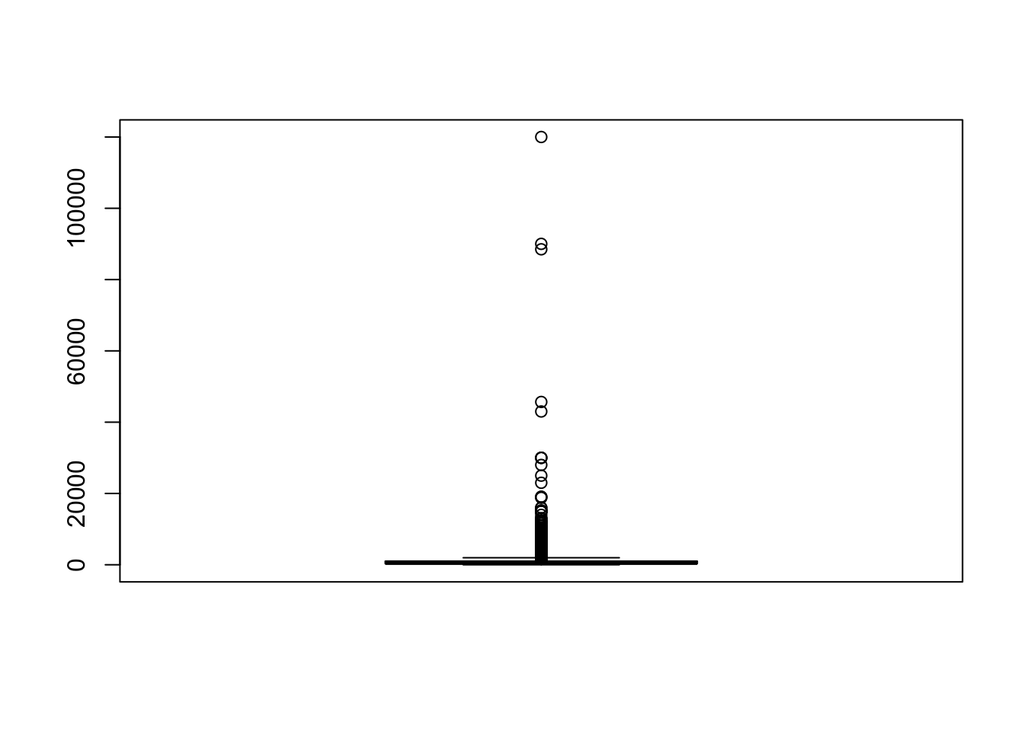

```r
boxplot(data$bike_price, col = "pink")
```

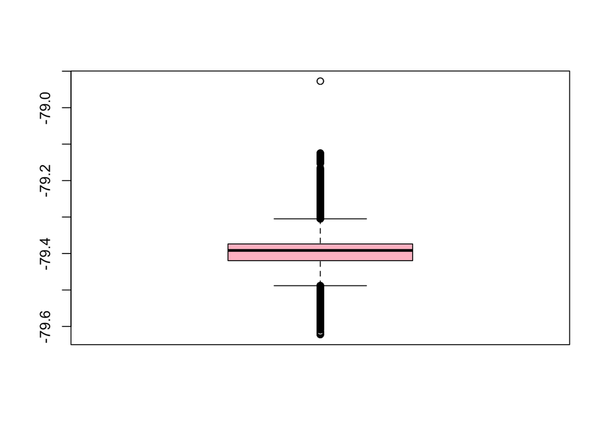

```r
boxplot(data$longitude, col = "pink")
```

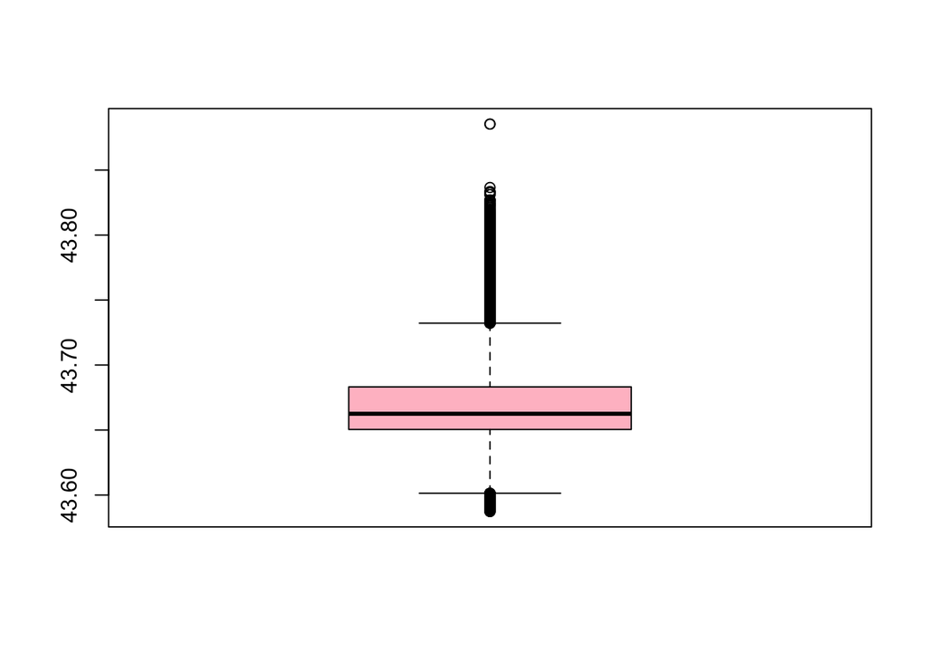

```r
boxplot(data$latitude, col = "pink")
```

```r
clean_data <- data[longitude > min(longitude)]
```

There are many bikes with extremely high price ($> p_{0.75} + 1.5 IQR$), which may be influential points when we build a regression model. However, I don’t think these are error data – if you google “Carbon Fiber Bicycle” you will find that these prices are “reasonable”. And the theft of such a valuable bicycle must be a very serious case, so it is necessary for us to keep this record. Since we have no valid reason to delete them, we will just keep these outliers.

## Step 3: Explore the main question of interest

#### Calculate summary statistics for each season.

```r
season_data <- clean_data %>% mutate(season = case_when(
  month =="March" | month =="April" | month =="May" ~ "spring",
  month =="June" | month =="July" | month =="August"  ~ "summer",
  month =="September" | month =="October" | month =="November" ~ "fall",
  month =="December" | month =="January" | month =="February" ~ "winter")) %>%
  group_by(year, season) %>%
  summarise(count = n())
season_data %>%
  group_by(season) %>%
  summarise(mean_count = mean(count),
            median_count = median(count),
            var_count = var(count))
```

```
## # A tibble: 4 × 4
##   season mean_count median_count var_count
##   <chr>       <dbl>        <dbl>     <dbl>
## 1 fall         740.         891    237906.
## 2 spring       586.         726     90542.
## 3 summer      1068.        1448.   552084.
## 4 winter       244.         291     11998.
```

#### Conduct basic analyses that enable me to compare across winter/spring/summer/fall.

```r
model <- lm(count ~ season, data=season_data)
summary(model)
```

```
##
## Call:
## lm(formula = count ~ season, data = season_data)
##
## Residuals:
##      Min       1Q   Median       3Q      Max
## -1065.67   -83.15    90.10   293.43   761.33
##
## Coefficients:
##              Estimate Std. Error t value Pr(>|t|)
## (Intercept)     740.3      146.7   5.047 1.02e-05 ***
## seasonspring   -154.5      207.4  -0.745   0.4608
## seasonsummer    327.4      203.1   1.612   0.1148
## seasonwinter   -496.4      212.5  -2.335   0.0246 *
## ---
## Signif. codes:  0 '***' 0.001 '**' 0.01 '*' 0.05 '.' 0.1 ' ' 1
##
## Residual standard error: 486.5 on 40 degrees of freedom
## Multiple R-squared:  0.2887, Adjusted R-squared:  0.2354
## F-statistic: 5.413 on 3 and 40 DF,  p-value: 0.003201
```

```r
anova(model)
```

```
## Analysis of Variance Table
##
## Response: count
##           Df  Sum Sq Mean Sq F value   Pr(>F)
## season     3 3842638 1280879  5.4129 0.003201 **
## Residuals 40 9465383  236635
## ---
## Signif. codes:  0 '***' 0.001 '**' 0.01 '*' 0.05 '.' 0.1 ' ' 1
```

## Step 4: Create exploratory plots

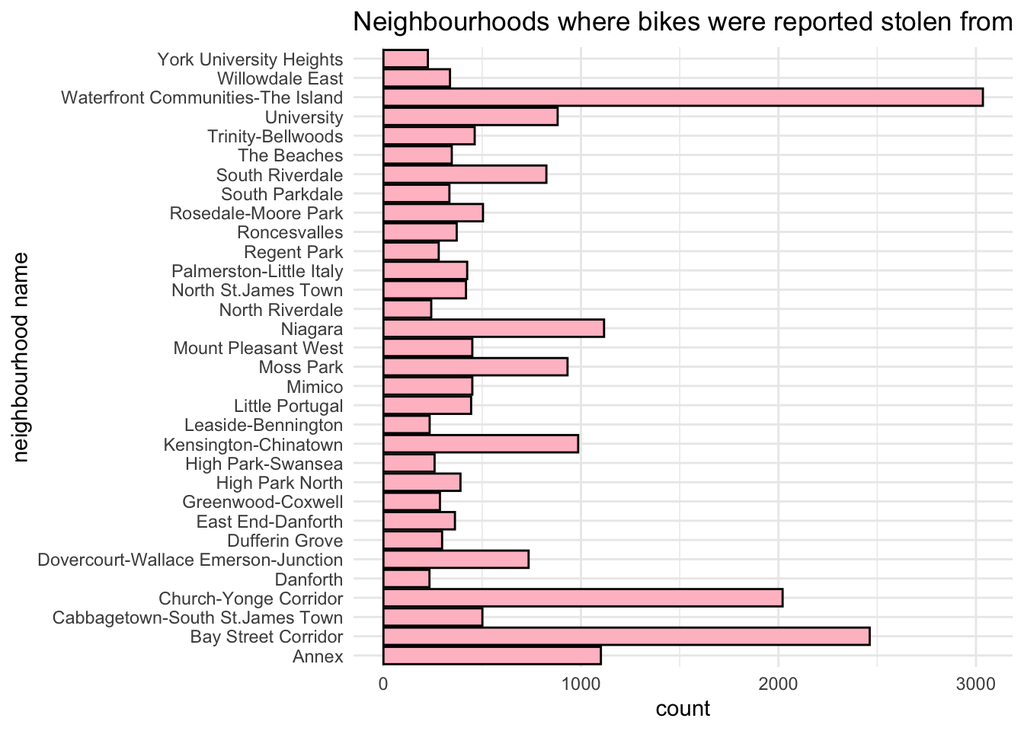

```r
clean_data %>%
  filter(!is.na(hood_name)) %>%
  group_by(hood_name) %>%
  count() %>%
  filter(n > 200) %>%
  ggplot() +
  geom_bar(aes(x = hood_name, y = n), color = 'black', fill = "pink", stat = "identity") +
  theme_minimal() +
  coord_flip() +
  labs(title = "Neighbourhoods where bikes were reported stolen from", x = "neighbourhood name", y = "count")
```

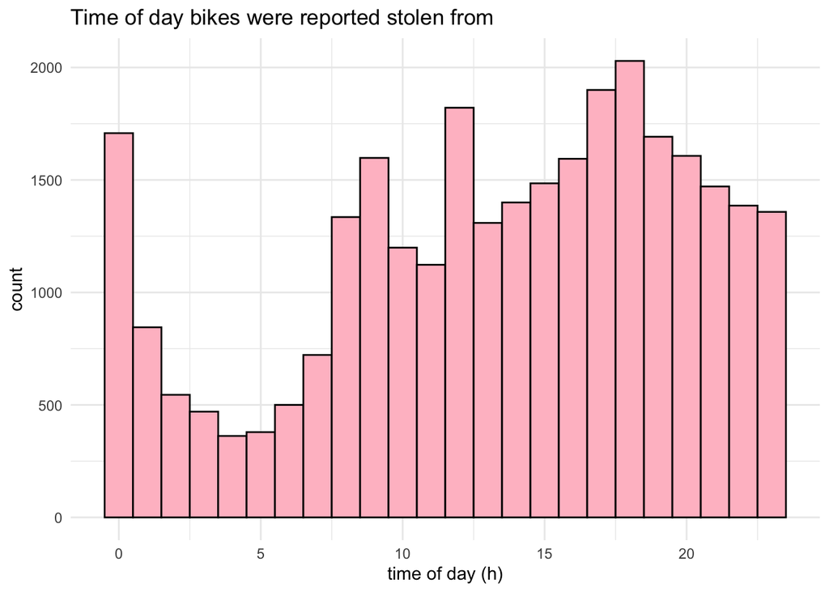

```r
ggplot(clean_data) +
  geom_histogram(aes(x = hour), color = 'black', fill = "pink", bins = 24) +
  theme_minimal() +
  labs(title = "Time of day bikes were reported stolen from", x = "time of day (h)", y = "count")
```

## Step 5: Create a basic map

```r
# error when knitting
#  factpal <- colorFactor(topo.colors(20), data$bike_color)
#
# data %>%
# leaflet() %>%
# addProviderTiles('OpenStreetMap') %>%
# addCircles(lat=~latitude, lng=~longitude, opacity=1, fillOpacity=1, color=~factpal(bike_color), radius=5)
#

un_data = clean_data %>% filter(bike_type == "UN")
table(un_data$bike_color)
```

```
##
## BLK GRN GRY RED WHI
##   3   1   2   2   1
```

```r
un_data <- un_data %>% mutate(bike_color = case_when(
  bike_color=="BLK" ~ "black",
  bike_color=="GRN" ~ "green",
  bike_color=="GRY" ~ "gray",
  bike_color=="WHI" ~ "white",
  bike_color=="RED" ~ "red"
))

leaflet(un_data) %>%
  addProviderTiles('OpenStreetMap') %>%
  addCircles(lat=~latitude, lng=~longitude, opacity=1, fillOpacity=1, color = ~bike_color, radius=5)
```

[interactive chart not shown]